# 1B_2702261914

```python
# import library deep learning
import torch
import torch.nn as nn
import torchvision
import torch.optim as optim

# import library
import pandas as pd
import numpy as np
import matplotlib.pyplot as plt
import seaborn as sns

from tensorflow.keras.models import Sequential
from tensorflow.keras.layers import Dense
from tensorflow.keras.optimizers import Adam

from sklearn.model_selection import train_test_split
from sklearn.preprocessing import StandardScaler # Import StandardScaler
!pip install scikit-learn
from sklearn.preprocessing import OrdinalEncoder
from sklearn.preprocessing import OneHotEncoder
```

video: https://drive.google.com/drive/folders/1sRZ9H5nQlWEh0j6vKuBSLvW_J-nq-8Ia?usp=sharing.

```python
# read file
from google.colab import drive
drive.mount('/content/drive')

df = pd.read_parquet('/content/drive/MyDrive/1B_Deep Learning/dataset_1B.parquet')
df
```

|  | date | quarter | day | Team Code | smv | wip | over_time | incentive | idle_time | idle_men | no_of_style_change | no_of_workers | productivity_score |
| --- | --- | --- | --- | --- | --- | --- | --- | --- | --- | --- | --- | --- | --- |
| 0 | 1/1/2015 | Quarter1 | Thursday | 8 | 26.16 | 1108.0 | 7080 | 98 | 0.0 | 0 | 0 | 59.0 | 94.073 |
| 1 | 1/1/2015 | Quarter1 | Thursday | 1 | 3.94 | NaN | 960 | 0 | 0.0 | 0 | 0 | 8.0 | 88.650 |
| 2 | 1/1/2015 | Quarter1 | Thursday | 11 | 11.41 | 968.0 | 3660 | 50 | 0.0 | 0 | 0 | 30.5 | 80.057 |
| 3 | 1/1/2015 | Quarter1 | Thursday | 12 | 11.41 | 968.0 | 3660 | 50 | 0.0 | 0 | 0 | 30.5 | 80.057 |
| 4 | 1/1/2015 | Quarter1 | Thursday | 6 | 25.90 | 1170.0 | 1920 | 50 | 0.0 | 0 | 0 | 56.0 | 80.038 |
| ... | ... | ... | ... | ... | ... | ... | ... | ... | ... | ... | ... | ... | ... |
| 1192 | 2016-03-10 | Quarter2 | Wednesday | 10 | 2.90 | NaN | 960 | 0 | 0.0 | 0 | 0 | 8.0 | 62.833 |
| 1193 | 2016-03-10 | Quarter2 | Wednesday | 8 | 3.90 | NaN | 960 | 0 | 0.0 | 0 | 0 | 8.0 | 62.562 |
| 1194 | 2016-03-10 | Quarter2 | Wednesday | 7 | 3.90 | NaN | 960 | 0 | 0.0 | 0 | 0 | 8.0 | 62.562 |
| 1195 | 2016-03-10 | Quarter2 | Wednesday | 9 | 2.90 | NaN | 1800 | 0 | 0.0 | 0 | 0 | 15.0 | 50.589 |
| 1196 | 2016-03-10 | Quarter2 | Wednesday | 6 | 2.90 | NaN | 720 | 0 | 0.0 | 0 | 0 | 6.0 | 39.472 |

1197 rows × 13 columns

```python
df.info()
```

```
<class 'pandas.core.frame.DataFrame'>
RangeIndex: 1197 entries, 0 to 1196
Data columns (total 13 columns):
 #   Column              Non-Null Count  Dtype
---  ------              --------------  -----
 0   date                1197 non-null   object
 1   quarter             1197 non-null   object
 2   day                 1197 non-null   object
 3   Team Code           1197 non-null   int64
 4   smv                 1197 non-null   float64
 5   wip                 691 non-null    float64
 6   over_time           1197 non-null   int64
 7   incentive           1197 non-null   int64
 8   idle_time           1197 non-null   float64
 9   idle_men            1197 non-null   int64
 10  no_of_style_change  1197 non-null   int64
 11  no_of_workers       1197 non-null   float64
 12  productivity_score  1197 non-null   float64
dtypes: float64(5), int64(5), object(3)
memory usage: 121.7+ KB
```

Dalam dataset ini memiliki 13 kolom dengan 1197 baris dan 3 jenis variabel yaitu: object, float, dan integer. Dapat dilihat bahwa dalam kolom wip terdapat missing value sebesar 506, yang perlu dilakukan imputasi.

```python
df.describe()
```

|  | Team Code | smv | wip | over_time | incentive | idle_time | idle_men | no_of_style_change | no_of_workers | productivity_score |
| --- | --- | --- | --- | --- | --- | --- | --- | --- | --- | --- |
| count | 1197.000000 | 1197.000000 | 691.000000 | 1197.000000 | 1197.000000 | 1197.000000 | 1197.000000 | 1197.000000 | 1197.000000 | 1197.000000 |
| mean | 6.426901 | 15.062172 | 1190.465991 | 4567.460317 | 38.210526 | 0.730159 | 0.369256 | 0.150376 | 34.337510 | 73.367040 |
| std | 3.463963 | 10.943219 | 1837.455001 | 3348.823563 | 160.182643 | 12.709757 | 3.268987 | 0.427848 | 22.617043 | 18.154945 |
| min | 1.000000 | 2.900000 | 7.000000 | 0.000000 | 0.000000 | 0.000000 | 0.000000 | 0.000000 | -57.000000 | -100.000000 |
| 25% | 3.000000 | 3.940000 | 774.500000 | 1440.000000 | 0.000000 | 0.000000 | 0.000000 | 0.000000 | 9.000000 | 65.030000 |
| 50% | 6.000000 | 15.260000 | 1039.000000 | 3960.000000 | 0.000000 | 0.000000 | 0.000000 | 0.000000 | 34.000000 | 77.333000 |
| 75% | 9.000000 | 24.260000 | 1252.500000 | 6960.000000 | 50.000000 | 0.000000 | 0.000000 | 0.000000 | 57.000000 | 85.025000 |
| max | 12.000000 | 54.560000 | 23122.000000 | 25920.000000 | 3600.000000 | 300.000000 | 45.000000 | 2.000000 | 89.000000 | 112.044000 |

Melalui penjelasan statistik deskriptif dari dataset, dapat ditemukan bahwa dalam kolom no_of_workers dan productivity_score memiliki nilai negatif yang perlu kita ubah ke absolut.

## Distribusi Data melalui Histogram

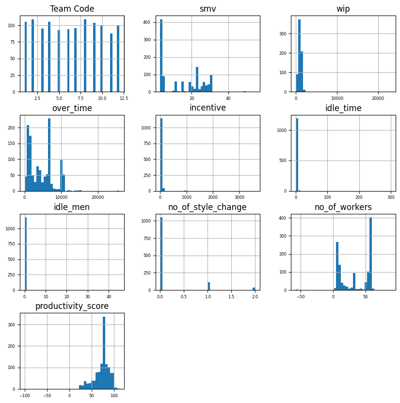

```python
df.hist(figsize=(10, 10), bins=40, xlabelsize=6, ylabelsize=6);
```

Distribusi data yang dapat dianalisis melalui histogram, dapat diketahui bahwa hampir semua kolom numerik dalam dataset ini tidak tersebar secara luas dan merata.

```python
df.duplicated().sum()
```

```
np.int64(0)
```

Tidak memiliki data yang berduplikat

```python
df.dtypes
```

|  | 0 |
| --- | --- |
| date | object |
| quarter | object |
| day | object |
| Team Code | int64 |
| smv | float64 |
| wip | float64 |
| over_time | int64 |
| incentive | int64 |
| idle_time | float64 |
| idle_men | int64 |
| no_of_style_change | int64 |
| no_of_workers | float64 |
| productivity_score | float64 |

**dtype:** object

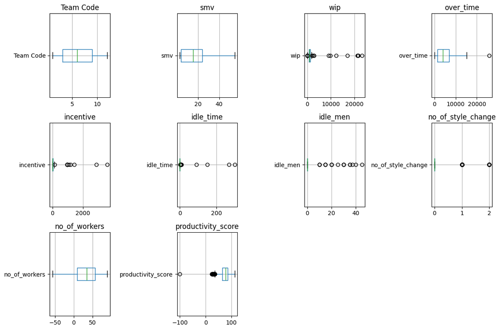

```python
plt.figure(figsize=(12, 8))
for i, col in enumerate(df.select_dtypes(include=['float64', 'int64']).columns):
    plt.subplot(3, 4, i + 1)
    df.boxplot(column=col, vert=False)
    plt.title(col)

plt.tight_layout()
plt.show()
```

Beberapa kalam banyak memiliki outliers seperti wip, incentive, productivity dsb. Setelah tau bahwa wip banyak outliersnya sehingga kita melakukan imputasi dengan menggunakan median

```python
# mencari unique value dalam kolom
df['quarter'].unique()
```

```
array(['Quarter1', 'Quarter2', 'Quarter3', 'Quarter4', 'Quarter5'],
      dtype=object)
```

```python
numerical_cols = df.select_dtypes(include=np.number).columns
df[numerical_cols].skew()
```

|  | 0 |
| --- | --- |
| Team Code | 0.009848 |
| smv | 0.405937 |
| wip | 9.741786 |
| over_time | 0.673287 |
| incentive | 15.790746 |
| idle_time | 20.545425 |
| idle_men | 9.855079 |
| no_of_style_change | 2.942506 |
| no_of_workers | -0.210580 |
| productivity_score | -1.424467 |

**dtype:** float64

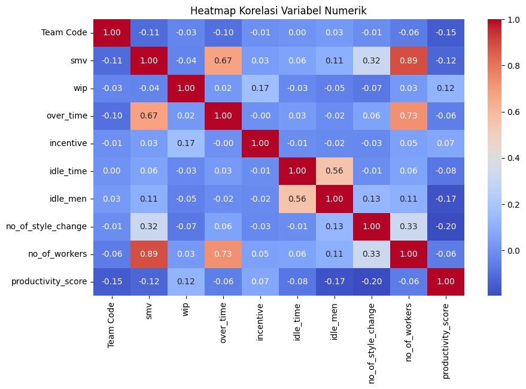

```python
# lihat korelasi variabel
numeric_cols = df.select_dtypes(include=np.number).columns
corr_matrix = df[numeric_cols].corr()

plt.figure(figsize=(10, 6))
sns.heatmap(corr_matrix, annot=True, cmap='coolwarm', fmt=".2f")
plt.title("Heatmap Korelasi Variabel Numerik")
plt.show()
```

```python
# Pastikan kolom date sudah dalam format datetime
df['date'] = pd.to_datetime(df['date'], errors='coerce', infer_datetime_format=True)

# Buat kolom day, month, dan year
df['days'] = df['date'].dt.day
df['month'] = df['date'].dt.month
df['year'] = df['date'].dt.year

# drop kolom date
df = df.drop('date', axis=1)
```

```python
# split data
X = df.drop(['productivity_score'], axis=1)
y = df['productivity_score']

X_train, X_temp, y_train, y_temp = train_test_split(X, y, test_size=0.3, random_state=42)
X_val, X_test, y_val, y_test = train_test_split(X_temp, y_temp, test_size=1/3, random_state=42)
```

```python
# ubah nilai negatif menjadi absolut
X_train['no_of_workers'] = X_train['no_of_workers'].abs()
X_train['productivity_score'] = y_train.abs()

X_val['no_of_workers'] = X_val['no_of_workers'].abs()
X_val['productivity_score'] = y_val.abs()

X_test['no_of_workers'] = X_test['no_of_workers'].abs()
X_test['productivity_score'] = y_test.abs()  #
```

```python
# Isi missing value dalam wip dengan median, dan memastikan bahwa semua angkanya tidak negatif
X_train['wip'] = X_train['wip'].fillna(X_train['wip'].median()).abs()
X_val['wip'] = X_val['wip'].fillna(X_val['wip'].median()).abs()
X_test['wip'] = X_test['wip'].fillna(X_test['wip'].median()).abs()
```

```python
# Encode Quarter
# Filter Quarter5
mask_train = X_train['quarter'] != 'Quarter5'
X_train = X_train[mask_train]
y_train = y_train[mask_train]

mask_val = X_val['quarter'] != 'Quarter5'
X_val = X_val[mask_val]
y_val = y_val[mask_val]

mask_test = X_test['quarter'] != 'Quarter5'
X_test = X_test[mask_test]
y_test = y_test[mask_test]

# Mapping quarter
quarter_map = {
    'Quarter1': 1,
    'Quarter2': 2,
    'Quarter3': 3,
    'Quarter4': 4
}


X_train['quarter'] = X_train['quarter'].map(quarter_map)
X_val['quarter'] = X_val['quarter'].map(quarter_map)
X_test['quarter'] = X_test['quarter'].map(quarter_map)

# kolom Day
df_binaryEncode = {
    "day": {"Monday": 1, "Tuesday": 2, "Wednesday": 3, "Thursday": 4, "Friday": 5, "Saturday": 6, "Sunday": 7}
}

# Replace values based on the dictionary
X_train = X_train.replace(df_binaryEncode)
X_val = X_val.replace(df_binaryEncode)
X_test = X_test.replace(df_binaryEncode)
```

```python
from sklearn.preprocessing import OneHotEncoder

# One Hot Encode kolom Team Code
# Initialize the encoder
encoder = OneHotEncoder(sparse_output=False, drop=None)

X_train_encoded = encoder.fit_transform(X_train[['Team Code']])
X_val_encoded = encoder.transform(X_val[['Team Code']])
X_test_encoded = encoder.transform(X_test[['Team Code']])

X_train_encoded = X_train_encoded.astype(int)
X_val_encoded = X_val_encoded.astype(int)
X_test_encoded = X_test_encoded.astype(int)

encoded_cols = encoder.get_feature_names_out(['Team Code'])

# Convert ke DataFrame
X_train_encoded_df = pd.DataFrame(X_train_encoded, columns=encoded_cols, index=X_train.index)
X_val_encoded_df = pd.DataFrame(X_val_encoded, columns=encoded_cols, index=X_val.index)
X_test_encoded_df = pd.DataFrame(X_test_encoded, columns=encoded_cols, index=X_test.index)

# Drop 'Team Code'
X_train_final = pd.concat([X_train.drop(columns=['Team Code']), X_train_encoded_df], axis=1)
X_val_final = pd.concat([X_val.drop(columns=['Team Code']), X_val_encoded_df], axis=1)
X_test_final = pd.concat([X_test.drop(columns=['Team Code']), X_test_encoded_df], axis=1)
```

```python
numeric_cols = X_train.select_dtypes(include=['int64', 'float64']).columns
categorical_cols = X_train.select_dtypes(include=['object']).columns
```

```python
# Scaling kolom numerik dalam input
scaler = StandardScaler()


X_train_num_scaled = scaler.fit_transform(X_train[numeric_cols])
X_val_num_scaled = scaler.transform(X_val[numeric_cols])
X_test_num_scaled = scaler.transform(X_test[numeric_cols])


X_train_scaled = pd.DataFrame(X_train_num_scaled, columns=numeric_cols, index=X_train.index)
X_val_scaled = pd.DataFrame(X_val_num_scaled, columns=numeric_cols, index=X_val.index)
X_test_scaled = pd.DataFrame(X_test_num_scaled, columns=numeric_cols, index=X_test.index)

X_train = pd.concat([X_train_scaled, X_train[categorical_cols]], axis=1)
X_val = pd.concat([X_val_scaled, X_val[categorical_cols]], axis=1)
X_test = pd.concat([X_test_scaled, X_test[categorical_cols]], axis=1)
```

```python
# drop kolom days, month, year
X_train = X_train.drop(['days', 'month', 'year'], axis=1)
X_val = X_val.drop(['days', 'month', 'year'], axis=1)
X_test = X_test.drop(['days', 'month', 'year'], axis=1)
```

```python
import tensorflow as tf
train_ds = tf.data.Dataset.from_tensor_slices((X_train, y_train)).batch(32).shuffle(10)
val_ds = tf.data.Dataset.from_tensor_slices((X_val, y_val)).batch(32)
test_ds = tf.data.Dataset.from_tensor_slices((X_test, y_test)).batch(32)
```

# Baseline Model

## Sequential

```python
from tensorflow.keras.models import Sequential
from tensorflow.keras.layers import Dense
from tensorflow.keras.optimizers import Adam

# Model Sequential baseline
model_1 = Sequential([
    Dense(64, activation='relu', input_shape=(X_train.shape[1],)),
    Dense(32, activation='relu'),
    Dense(1) # REGRESSION
])

# Compile model
model_1.compile(optimizer=Adam(),
                loss='mse',
                metrics=['mae', 'mse'])
```

```python
history_1 = model_1.fit(
    X_train, y_train,
    validation_data=(X_val, y_val),
    epochs=10,
    batch_size=32
)
```

```
26/26 ━━━━━━━━━━━━━━━━━━━━ 4s 29ms/step - loss: 5608.4995 - mae: 72.6738 - mse: 5608.4995 - val_loss: 5478.8159 - val_mae: 72.0950 - val_mse: 5478.8159
26/26 ━━━━━━━━━━━━━━━━━━━━ 0s 14ms/step - loss: 5305.3350 - mae: 70.5157 - mse: 5305.3350 - val_loss: 5117.4229 - val_mae: 69.5109 - val_mse: 5117.4229
26/26 ━━━━━━━━━━━━━━━━━━━━ 0s 12ms/step - loss: 4968.7827 - mae: 68.3071 - mse: 4968.7827 - val_loss: 4493.1147 - val_mae: 65.0977 - val_mse: 4493.1147
26/26 ━━━━━━━━━━━━━━━━━━━━ 1s 11ms/step - loss: 4262.0308 - mae: 63.0489 - mse: 4262.0308 - val_loss: 3511.0349 - val_mae: 57.3154 - val_mse: 3511.0349
26/26 ━━━━━━━━━━━━━━━━━━━━ 0s 11ms/step - loss: 3191.4429 - mae: 54.0465 - mse: 3191.4429 - val_loss: 2251.2720 - val_mae: 45.1369 - val_mse: 2251.2720
26/26 ━━━━━━━━━━━━━━━━━━━━ 1s 19ms/step - loss: 1823.7473 - mae: 40.0034 - mse: 1823.7473 - val_loss: 1104.0958 - val_mae: 29.7192 - val_mse: 1104.0958
26/26 ━━━━━━━━━━━━━━━━━━━━ 1s 25ms/step - loss: 784.6028 - mae: 24.9568 - mse: 784.6028 - val_loss: 461.9719 - val_mae: 15.7186 - val_mse: 461.9719
26/26 ━━━━━━━━━━━━━━━━━━━━ 1s 21ms/step - loss: 320.7976 - mae: 13.8228 - mse: 320.7976 - val_loss: 260.4777 - val_mae: 10.3787 - val_mse: 260.4777
26/26 ━━━━━━━━━━━━━━━━━━━━ 1s 27ms/step - loss: 220.9351 - mae: 10.9008 - mse: 220.9351 - val_loss: 195.0323 - val_mae: 8.8019 - val_mse: 195.0323
26/26 ━━━━━━━━━━━━━━━━━━━━ 1s 16ms/step - loss: 145.4080 - mae: 8.6145 - mse: 145.4080 - val_loss: 161.4959 - val_mae: 8.0131 - val_mse: 161.4959
```

```
8/8 ━━━━━━━━━━━━━━━━━━━━ 0s 13ms/step
R² Score: 0.4148
MAE: 8.0131
MSE: 161.4959
```

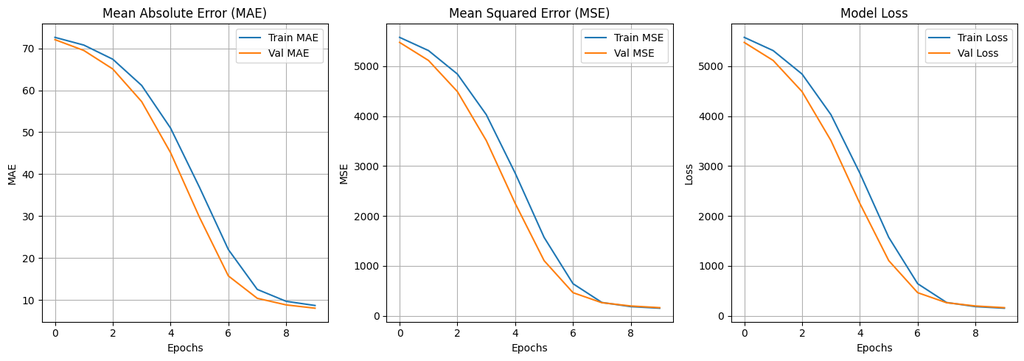

```python
import matplotlib.pyplot as plt
from sklearn.metrics import r2_score, mean_absolute_error, mean_squared_error

# Prediksi dari model
y_pred = model_1.predict(X_val)

# Hitung metrik
r2 = r2_score(y_val, y_pred)
mae = mean_absolute_error(y_val, y_pred)
mse = mean_squared_error(y_val, y_pred)

print(f'R² Score: {r2:.4f}')
print(f'MAE: {mae:.4f}')
print(f'MSE: {mse:.4f}')

# Plot MAE dan MSE
plt.figure(figsize=(14, 5))

# MAE
plt.subplot(1, 3, 1)
plt.plot(history_1.history['mae'], label='Train MAE')
plt.plot(history_1.history['val_mae'], label='Val MAE')
plt.title('Mean Absolute Error (MAE)')
plt.xlabel('Epochs')
plt.ylabel('MAE')
plt.legend()
plt.grid(True)

# MSE
plt.subplot(1, 3, 2)
plt.plot(history_1.history['mse'], label='Train MSE')
plt.plot(history_1.history['val_mse'], label='Val MSE')
plt.title('Mean Squared Error (MSE)')
plt.xlabel('Epochs')
plt.ylabel('MSE')
plt.legend()
plt.grid(True)

# Loss (sama dengan MSE jika loss='mse')
plt.subplot(1, 3, 3)
plt.plot(history_1.history['loss'], label='Train Loss')
plt.plot(history_1.history['val_loss'], label='Val Loss')
plt.title('Model Loss')
plt.xlabel('Epochs')
plt.ylabel('Loss')
plt.legend()
plt.grid(True)

plt.tight_layout()
plt.show()
```

Prediksi pada Baseline Sequential

## Functional

```python
from tensorflow.keras.models import Model
from tensorflow.keras.layers import Input, Dense

inputs = Input(shape=(X_train.shape[1],))

# Hidden layers
x = Dense(64, activation='relu')(inputs)
x = Dense(32, activation='relu')(x)

# Output layer
outputs = Dense(1)(x)

# Model
model_2 = Model(inputs=inputs, outputs=outputs)

# Compile
model_2.compile(optimizer=Adam(),
                loss='mse',
                metrics=['mae', 'mse'])
```

```python
history_2 = model_2.fit(
    X_train, y_train,
    validation_data=(X_val, y_val),
    epochs=10,
    batch_size=32
)
```

```
26/26 ━━━━━━━━━━━━━━━━━━━━ 4s 46ms/step - loss: 5619.9736 - mae: 72.7701 - mse: 5619.9736 - val_loss: 5529.8564 - val_mae: 72.4885 - val_mse: 5529.8564
26/26 ━━━━━━━━━━━━━━━━━━━━ 2s 22ms/step - loss: 5471.1172 - mae: 71.8959 - mse: 5471.1172 - val_loss: 5274.7642 - val_mae: 70.6910 - val_mse: 5274.7642
26/26 ━━━━━━━━━━━━━━━━━━━━ 0s 12ms/step - loss: 5133.3325 - mae: 69.4166 - mse: 5133.3325 - val_loss: 4838.3755 - val_mae: 67.5161 - val_mse: 4838.3755
26/26 ━━━━━━━━━━━━━━━━━━━━ 1s 20ms/step - loss: 4519.5977 - mae: 64.7355 - mse: 4519.5977 - val_loss: 4132.5518 - val_mae: 62.1547 - val_mse: 4132.5518
26/26 ━━━━━━━━━━━━━━━━━━━━ 1s 19ms/step - loss: 3800.7009 - mae: 59.2275 - mse: 3800.7009 - val_loss: 3127.8149 - val_mae: 53.7229 - val_mse: 3127.8149
26/26 ━━━━━━━━━━━━━━━━━━━━ 1s 20ms/step - loss: 2806.1260 - mae: 50.3034 - mse: 2806.1260 - val_loss: 1949.2463 - val_mae: 41.7754 - val_mse: 1949.2463
26/26 ━━━━━━━━━━━━━━━━━━━━ 1s 21ms/step - loss: 1586.0115 - mae: 36.8897 - mse: 1586.0115 - val_loss: 930.7170 - val_mae: 27.9088 - val_mse: 930.7170
26/26 ━━━━━━━━━━━━━━━━━━━━ 1s 23ms/step - loss: 741.8555 - mae: 24.2831 - mse: 741.8555 - val_loss: 352.1742 - val_mae: 16.0275 - val_mse: 352.1742
26/26 ━━━━━━━━━━━━━━━━━━━━ 1s 30ms/step - loss: 303.5630 - mae: 14.2044 - mse: 303.5630 - val_loss: 177.9164 - val_mae: 9.8708 - val_mse: 177.9164
26/26 ━━━━━━━━━━━━━━━━━━━━ 1s 7ms/step - loss: 177.0062 - mae: 9.6368 - mse: 177.0062 - val_loss: 137.5638 - val_mae: 8.5821 - val_mse: 137.5638
```

```
8/8 ━━━━━━━━━━━━━━━━━━━━ 0s 8ms/step
R² Score: 0.5015
MAE: 8.5821
MSE: 137.5638
```

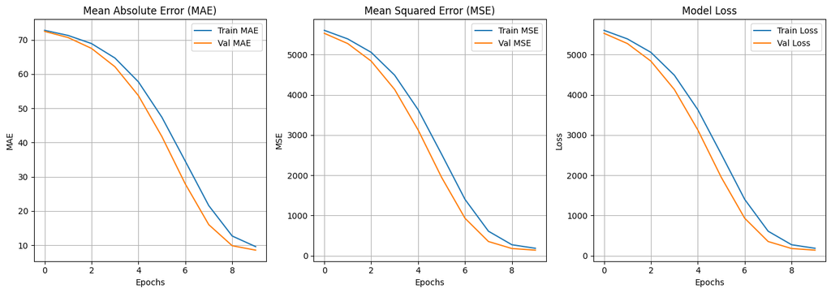

```python
import matplotlib.pyplot as plt
from sklearn.metrics import r2_score, mean_absolute_error, mean_squared_error

# Prediksi dari model
y_pred = model_2.predict(X_val)

# Hitung metrik
r2 = r2_score(y_val, y_pred)
mae = mean_absolute_error(y_val, y_pred)
mse = mean_squared_error(y_val, y_pred)

# Tampilkan metrik
print(f'R² Score: {r2:.4f}')
print(f'MAE: {mae:.4f}')
print(f'MSE: {mse:.4f}')

# Plot MAE dan MSE
plt.figure(figsize=(14, 5))

# MAE
plt.subplot(1, 3, 1)
plt.plot(history_2.history['mae'], label='Train MAE')
plt.plot(history_2.history['val_mae'], label='Val MAE')
plt.title('Mean Absolute Error (MAE)')
plt.xlabel('Epochs')
plt.ylabel('MAE')
plt.legend()
plt.grid(True)

# MSE
plt.subplot(1, 3, 2)
plt.plot(history_2.history['mse'], label='Train MSE')
plt.plot(history_2.history['val_mse'], label='Val MSE')
plt.title('Mean Squared Error (MSE)')
plt.xlabel('Epochs')
plt.ylabel('MSE')
plt.legend()
plt.grid(True)

# Loss (sama dengan MSE jika loss='mse')
plt.subplot(1, 3, 3)
plt.plot(history_2.history['loss'], label='Train Loss')
plt.plot(history_2.history['val_loss'], label='Val Loss')
plt.title('Model Loss')
plt.xlabel('Epochs')
plt.ylabel('Loss')
plt.legend()
plt.grid(True)

plt.tight_layout()
plt.show()
```

Memiliki prediksi yang hampir sama dengan sequential, namun tetap ada perbedaan nilai sedikit. Mungkin terjadi karena perbedaan arsitekturnya

## Sequential

```python
from tensorflow.keras.models import Sequential
from tensorflow.keras.layers import Dense, ELU, Dropout, BatchNormalization
from tensorflow.keras.optimizers import Adam
from tensorflow.keras.callbacks import EarlyStopping, ReduceLROnPlateau

# Model definition
model_1_mod = Sequential([
    Dense(256), ELU(),
    BatchNormalization(),
    Dropout(0.2),

    Dense(128), ELU(),
    BatchNormalization(),
    Dropout(0.2),

    Dense(64), ELU(),
    BatchNormalization(),
    Dropout(0.2),

    Dense(32), ELU(),
    BatchNormalization(),
    Dense(1)  # Output layer (regression)
])

# Compile the model with lower learning rate
optimizer = Adam(learning_rate=0.0001)  # Lower learning rate for stability
model_1_mod.compile(optimizer=optimizer, loss='mse', metrics=['mae', 'mse'])

# Define callbacks
early_stopping = EarlyStopping(monitor='val_loss', patience=10, restore_best_weights=True)
lr_scheduler = ReduceLROnPlateau(monitor='val_loss', factor=0.5, patience=5, min_lr=1e-6)
```

```python
# Train the model with callbacks
history_1_mod = model_1_mod.fit(
    X_train, y_train,
    validation_data=(X_val, y_val),
    epochs=100,
    batch_size=32,
    verbose=1,
    callbacks=[early_stopping, lr_scheduler]
)
```

```
26/26 ━━━━━━━━━━━━━━━━━━━━ 5s 22ms/step - loss: 5638.9814 - mae: 72.9888 - mse: 5638.9814 - val_loss: 5628.0430 - val_mae: 73.2787 - val_mse: 5628.0430 - learning_rate: 1.0000e-04
26/26 ━━━━━━━━━━━━━━━━━━━━ 0s 8ms/step - loss: 5684.4150 - mae: 73.5901 - mse: 5684.4150 - val_loss: 5591.6543 - val_mae: 73.1275 - val_mse: 5591.6543 - learning_rate: 1.0000e-04
26/26 ━━━━━━━━━━━━━━━━━━━━ 0s 9ms/step - loss: 5551.1885 - mae: 72.9446 - mse: 5551.1885 - val_loss: 5562.4414 - val_mae: 73.0333 - val_mse: 5562.4414 - learning_rate: 1.0000e-04
26/26 ━━━━━━━━━━━━━━━━━━━━ 0s 8ms/step - loss: 5502.7417 - mae: 72.7829 - mse: 5502.7417 - val_loss: 5535.9233 - val_mae: 72.9673 - val_mse: 5535.9233 - learning_rate: 1.0000e-04
26/26 ━━━━━━━━━━━━━━━━━━━━ 0s 8ms/step - loss: 5520.8105 - mae: 73.0706 - mse: 5520.8105 - val_loss: 5511.5884 - val_mae: 72.9113 - val_mse: 5511.5884 - learning_rate: 1.0000e-04
26/26 ━━━━━━━━━━━━━━━━━━━━ 0s 8ms/step - loss: 5392.0254 - mae: 72.1364 - mse: 5392.0254 - val_loss: 5490.3892 - val_mae: 72.8814 - val_mse: 5490.3892 - learning_rate: 1.0000e-04
26/26 ━━━━━━━━━━━━━━━━━━━━ 0s 9ms/step - loss: 5462.8096 - mae: 72.7038 - mse: 5462.8096 - val_loss: 5471.8379 - val_mae: 72.8483 - val_mse: 5471.8379 - learning_rate: 1.0000e-04
26/26 ━━━━━━━━━━━━━━━━━━━━ 0s 8ms/step - loss: 5430.2075 - mae: 72.6307 - mse: 5430.2075 - val_loss: 5456.5366 - val_mae: 72.8338 - val_mse: 5456.5366 - learning_rate: 1.0000e-04
26/26 ━━━━━━━━━━━━━━━━━━━━ 0s 8ms/step - loss: 5412.6821 - mae: 72.4822 - mse: 5412.6821 - val_loss: 5444.0220 - val_mae: 72.8324 - val_mse: 5444.0220 - learning_rate: 1.0000e-04
26/26 ━━━━━━━━━━━━━━━━━━━━ 0s 8ms/step - loss: 5428.6152 - mae: 72.6280 - mse: 5428.6152 - val_loss: 5432.6455 - val_mae: 72.8157 - val_mse: 5432.6455 - learning_rate: 1.0000e-04
26/26 ━━━━━━━━━━━━━━━━━━━━ 0s 8ms/step - loss: 5570.2935 - mae: 73.6852 - mse: 5570.2935 - val_loss: 5417.1870 - val_mae: 72.7670 - val_mse: 5417.1870 - learning_rate: 1.0000e-04
26/26 ━━━━━━━━━━━━━━━━━━━━ 0s 8ms/step - loss: 5460.9038 - mae: 72.8496 - mse: 5460.9038 - val_loss: 5409.1895 - val_mae: 72.7657 - val_mse: 5409.1895 - learning_rate: 1.0000e-04
26/26 ━━━━━━━━━━━━━━━━━━━━ 0s 9ms/step - loss: 5589.7246 - mae: 73.8985 - mse: 5589.7246 - val_loss: 5403.3027 - val_mae: 72.7696 - val_mse: 5403.3027 - learning_rate: 1.0000e-04
26/26 ━━━━━━━━━━━━━━━━━━━━ 0s 13ms/step - loss: 5391.5024 - mae: 72.5233 - mse: 5391.5024 - val_loss: 5403.3291 - val_mae: 72.8097 - val_mse: 5403.3291 - learning_rate: 1.0000e-04
26/26 ━━━━━━━━━━━━━━━━━━━━ 0s 13ms/step - loss: 5428.1284 - mae: 72.8736 - mse: 5428.1284 - val_loss: 5382.1372 - val_mae: 72.6880 - val_mse: 5382.1372 - learning_rate: 1.0000e-04
26/26 ━━━━━━━━━━━━━━━━━━━━ 1s 13ms/step - loss: 5345.4756 - mae: 72.2446 - mse: 5345.4756 - val_loss: 5382.6714 - val_mae: 72.7244 - val_mse: 5382.6714 - learning_rate: 1.0000e-04
26/26 ━━━━━━━━━━━━━━━━━━━━ 0s 12ms/step - loss: 5407.8169 - mae: 72.7597 - mse: 5407.8169 - val_loss: 5377.9004 - val_mae: 72.7148 - val_mse: 5377.9004 - learning_rate: 1.0000e-04
26/26 ━━━━━━━━━━━━━━━━━━━━ 1s 11ms/step - loss: 5461.9189 - mae: 73.1299 - mse: 5461.9189 - val_loss: 5372.0122 - val_mae: 72.6949 - val_mse: 5372.0122 - learning_rate: 1.0000e-04
26/26 ━━━━━━━━━━━━━━━━━━━━ 1s 13ms/step - loss: 5461.5625 - mae: 73.1624 - mse: 5461.5625 - val_loss: 5362.6147 - val_mae: 72.6478 - val_mse: 5362.6147 - learning_rate: 1.0000e-04
26/26 ━━━━━━━━━━━━━━━━━━━━ 0s 8ms/step - loss: 5355.0117 - mae: 72.3730 - mse: 5355.0117 - val_loss: 5355.0063 - val_mae: 72.6151 - val_mse: 5355.0063 - learning_rate: 1.0000e-04
26/26 ━━━━━━━━━━━━━━━━━━━━ 0s 8ms/step - loss: 5409.8218 - mae: 72.7919 - mse: 5409.8218 - val_loss: 5355.1934 - val_mae: 72.6268 - val_mse: 5355.1934 - learning_rate: 1.0000e-04
26/26 ━━━━━━━━━━━━━━━━━━━━ 0s 8ms/step - loss: 5404.1182 - mae: 72.8158 - mse: 5404.1182 - val_loss: 5346.2271 - val_mae: 72.5769 - val_mse: 5346.2271 - learning_rate: 1.0000e-04
26/26 ━━━━━━━━━━━━━━━━━━━━ 0s 8ms/step - loss: 5284.7832 - mae: 71.9700 - mse: 5284.7832 - val_loss: 5339.9517 - val_mae: 72.5453 - val_mse: 5339.9517 - learning_rate: 1.0000e-04
26/26 ━━━━━━━━━━━━━━━━━━━━ 0s 8ms/step - loss: 5469.6968 - mae: 73.2633 - mse: 5469.6968 - val_loss: 5341.0854 - val_mae: 72.5699 - val_mse: 5341.0854 - learning_rate: 1.0000e-04
26/26 ━━━━━━━━━━━━━━━━━━━━ 0s 8ms/step - loss: 5399.9351 - mae: 72.8319 - mse: 5399.9351 - val_loss: 5338.9536 - val_mae: 72.5630 - val_mse: 5338.9536 - learning_rate: 1.0000e-04
26/26 ━━━━━━━━━━━━━━━━━━━━ 0s 8ms/step - loss: 5297.5029 - mae: 72.0590 - mse: 5297.5029 - val_loss: 5339.3872 - val_mae: 72.5760 - val_mse: 5339.3872 - learning_rate: 1.0000e-04
```

[output cut: 74 more lines]

```
WARNING:tensorflow:5 out of the last 17 calls to <function TensorFlowTrainer.make_predict_function.<locals>.one_step_on_data_distributed at 0x79e1643e0a40> triggered tf.function retracing. Tracing is expensive and the excessive number of tracings could be due to (1) creating @tf.function repeatedly …
```

```
8/8 ━━━━━━━━━━━━━━━━━━━━ 0s 22ms/step
R² Score: -16.0702
MAE: 68.3866
MSE: 4710.5428
```

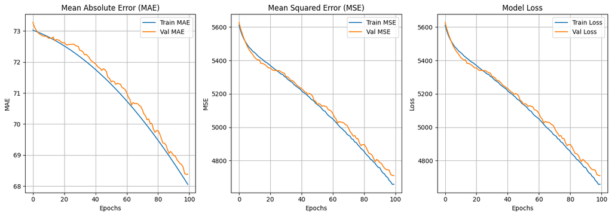

```python
import matplotlib.pyplot as plt
from sklearn.metrics import r2_score, mean_absolute_error, mean_squared_error

# Prediksi dari model
y_pred = model_1_mod.predict(X_val)

# Hitung metrik
r2 = r2_score(y_val, y_pred)
mae = mean_absolute_error(y_val, y_pred)
mse = mean_squared_error(y_val, y_pred)

# Tampilkan metrik
print(f'R² Score: {r2:.4f}')
print(f'MAE: {mae:.4f}')
print(f'MSE: {mse:.4f}')

# Plot MAE dan MSE
plt.figure(figsize=(14, 5))

# MAE
plt.subplot(1, 3, 1)
plt.plot(history_1_mod.history['mae'], label='Train MAE')
plt.plot(history_1_mod.history['val_mae'], label='Val MAE')
plt.title('Mean Absolute Error (MAE)')
plt.xlabel('Epochs')
plt.ylabel('MAE')
plt.legend()
plt.grid(True)

# MSE
plt.subplot(1, 3, 2)
plt.plot(history_1_mod.history['mse'], label='Train MSE')
plt.plot(history_1_mod.history['val_mse'], label='Val MSE')
plt.title('Mean Squared Error (MSE)')
plt.xlabel('Epochs')
plt.ylabel('MSE')
plt.legend()
plt.grid(True)

# Loss (sama dengan MSE jika loss='mse')
plt.subplot(1, 3, 3)
plt.plot(history_1_mod.history['loss'], label='Train Loss')
plt.plot(history_1_mod.history['val_loss'], label='Val Loss')
plt.title('Model Loss')
plt.xlabel('Epochs')
plt.ylabel('Loss')
plt.legend()
plt.grid(True)

plt.tight_layout()
plt.show()
```

Walaupun grafik training menunjukkan bahwa modelnya belajar dengan stabil, tapihasil akhirnya buruk karena: 1. R² Score negatif berarti lebih buruk dari tebakan rata-rata. 2. MAE dan MSE masih tinggi, jadi model belum menangkap pola yang bener.

## Functional

```python
from tensorflow.keras.models import Model
from tensorflow.keras.layers import Input, Dense, Dropout, BatchNormalization, Activation
from tensorflow.keras.optimizers import Adam
from tensorflow.keras.callbacks import ReduceLROnPlateau

# Input layer
inputs = Input(shape=(X_train.shape[1],))

# Hidden layers
x = Dense(512)(inputs)
x = BatchNormalization()(x)
x = Activation("relu")(x)
x = Dropout(0.4)(x)

x = Dense(256)(x)
x = BatchNormalization()(x)
x = Activation("relu")(x)
x = Dropout(0.3)(x)

x = Dense(128)(x)
x = BatchNormalization()(x)
x = Activation("elu")(x)
x = Dropout(0.2)(x)

x = Dense(64)(x)
x = BatchNormalization()(x)
x = Activation("relu")(x)

# Output layer
outputs = Dense(1)(x)

# Model
model_2_mod = Model(inputs=inputs, outputs=outputs)

# Optimizer dan Learning Rate Scheduler
optimizer = Adam(learning_rate=0.001)
lr_scheduler = ReduceLROnPlateau(monitor='val_loss', factor=0.5, patience=5, min_lr=1e-6)

# Compile model
model_2_mod.compile(optimizer=optimizer,
                    loss='mse',
                    metrics=['mae', 'mse'])

# Training model
history_2_mod = model_2_mod.fit(
    X_train, y_train,
    validation_data=(X_val, y_val),
    epochs=100,
    batch_size=32,
    verbose=1,
    callbacks=[lr_scheduler]
)
```

```
26/26 ━━━━━━━━━━━━━━━━━━━━ 5s 24ms/step - loss: 5753.0083 - mae: 74.1511 - mse: 5753.0083 - val_loss: 5650.8833 - val_mae: 73.6003 - val_mse: 5650.8833 - learning_rate: 0.0010
26/26 ━━━━━━━━━━━━━━━━━━━━ 1s 12ms/step - loss: 5567.5146 - mae: 73.3039 - mse: 5567.5146 - val_loss: 5497.2456 - val_mae: 72.7979 - val_mse: 5497.2456 - learning_rate: 0.0010
26/26 ━━━━━━━━━━━━━━━━━━━━ 0s 11ms/step - loss: 5390.2754 - mae: 72.3247 - mse: 5390.2754 - val_loss: 5315.5117 - val_mae: 71.6349 - val_mse: 5315.5117 - learning_rate: 0.0010
26/26 ━━━━━━━━━━━━━━━━━━━━ 1s 13ms/step - loss: 5186.3472 - mae: 70.8958 - mse: 5186.3472 - val_loss: 5108.1143 - val_mae: 70.2465 - val_mse: 5108.1143 - learning_rate: 0.0010
26/26 ━━━━━━━━━━━━━━━━━━━━ 1s 20ms/step - loss: 4990.0181 - mae: 69.5860 - mse: 4990.0181 - val_loss: 4839.4580 - val_mae: 68.4655 - val_mse: 4839.4580 - learning_rate: 0.0010
26/26 ━━━━━━━━━━━━━━━━━━━━ 1s 21ms/step - loss: 4883.1489 - mae: 68.9042 - mse: 4883.1489 - val_loss: 4663.9248 - val_mae: 67.2184 - val_mse: 4663.9248 - learning_rate: 0.0010
26/26 ━━━━━━━━━━━━━━━━━━━━ 0s 18ms/step - loss: 4700.4121 - mae: 67.3987 - mse: 4700.4121 - val_loss: 4477.2549 - val_mae: 65.9271 - val_mse: 4477.2549 - learning_rate: 0.0010
26/26 ━━━━━━━━━━━━━━━━━━━━ 1s 17ms/step - loss: 4532.5688 - mae: 66.3832 - mse: 4532.5688 - val_loss: 4224.7251 - val_mae: 64.0866 - val_mse: 4224.7251 - learning_rate: 0.0010
26/26 ━━━━━━━━━━━━━━━━━━━━ 1s 21ms/step - loss: 4300.2061 - mae: 64.4891 - mse: 4300.2061 - val_loss: 4043.5459 - val_mae: 62.6459 - val_mse: 4043.5459 - learning_rate: 0.0010
26/26 ━━━━━━━━━━━━━━━━━━━━ 0s 11ms/step - loss: 4097.1831 - mae: 62.9024 - mse: 4097.1831 - val_loss: 3788.1108 - val_mae: 60.6657 - val_mse: 3788.1108 - learning_rate: 0.0010
26/26 ━━━━━━━━━━━━━━━━━━━━ 1s 11ms/step - loss: 3810.3435 - mae: 60.6556 - mse: 3810.3435 - val_loss: 3586.2893 - val_mae: 58.9808 - val_mse: 3586.2893 - learning_rate: 0.0010
26/26 ━━━━━━━━━━━━━━━━━━━━ 0s 12ms/step - loss: 3693.9700 - mae: 59.7240 - mse: 3693.9700 - val_loss: 3333.4436 - val_mae: 56.8724 - val_mse: 3333.4436 - learning_rate: 0.0010
26/26 ━━━━━━━━━━━━━━━━━━━━ 0s 11ms/step - loss: 3578.7383 - mae: 58.8974 - mse: 3578.7383 - val_loss: 2981.5549 - val_mae: 53.7214 - val_mse: 2981.5549 - learning_rate: 0.0010
26/26 ━━━━━━━━━━━━━━━━━━━━ 0s 12ms/step - loss: 3277.8220 - mae: 56.3632 - mse: 3277.8220 - val_loss: 2795.7615 - val_mae: 51.9998 - val_mse: 2795.7615 - learning_rate: 0.0010
26/26 ━━━━━━━━━━━━━━━━━━━━ 0s 11ms/step - loss: 3081.1567 - mae: 54.5866 - mse: 3081.1567 - val_loss: 2501.5825 - val_mae: 49.1249 - val_mse: 2501.5825 - learning_rate: 0.0010
26/26 ━━━━━━━━━━━━━━━━━━━━ 0s 11ms/step - loss: 2840.1882 - mae: 52.5380 - mse: 2840.1882 - val_loss: 2296.9456 - val_mae: 47.0366 - val_mse: 2296.9456 - learning_rate: 0.0010
26/26 ━━━━━━━━━━━━━━━━━━━━ 1s 11ms/step - loss: 2515.1787 - mae: 49.2958 - mse: 2515.1787 - val_loss: 2182.6018 - val_mae: 45.8600 - val_mse: 2182.6018 - learning_rate: 0.0010
26/26 ━━━━━━━━━━━━━━━━━━━━ 0s 11ms/step - loss: 2461.7095 - mae: 48.7631 - mse: 2461.7095 - val_loss: 1958.3542 - val_mae: 43.4077 - val_mse: 1958.3542 - learning_rate: 0.0010
26/26 ━━━━━━━━━━━━━━━━━━━━ 0s 11ms/step - loss: 2059.7124 - mae: 44.5282 - mse: 2059.7124 - val_loss: 1764.1060 - val_mae: 41.1894 - val_mse: 1764.1060 - learning_rate: 0.0010
26/26 ━━━━━━━━━━━━━━━━━━━━ 0s 11ms/step - loss: 1984.4418 - mae: 43.8054 - mse: 1984.4418 - val_loss: 1636.8794 - val_mae: 39.7861 - val_mse: 1636.8794 - learning_rate: 0.0010
26/26 ━━━━━━━━━━━━━━━━━━━━ 0s 11ms/step - loss: 1701.8938 - mae: 40.5561 - mse: 1701.8938 - val_loss: 1453.9012 - val_mae: 37.3984 - val_mse: 1453.9012 - learning_rate: 0.0010
26/26 ━━━━━━━━━━━━━━━━━━━━ 0s 11ms/step - loss: 1515.9487 - mae: 38.1296 - mse: 1515.9487 - val_loss: 1129.1187 - val_mae: 32.9076 - val_mse: 1129.1187 - learning_rate: 0.0010
26/26 ━━━━━━━━━━━━━━━━━━━━ 1s 10ms/step - loss: 1236.7079 - mae: 34.1814 - mse: 1236.7079 - val_loss: 1063.5929 - val_mae: 31.9655 - val_mse: 1063.5929 - learning_rate: 0.0010
26/26 ━━━━━━━━━━━━━━━━━━━━ 0s 11ms/step - loss: 1047.5046 - mae: 31.4893 - mse: 1047.5046 - val_loss: 832.5508 - val_mae: 28.2092 - val_mse: 832.5508 - learning_rate: 0.0010
26/26 ━━━━━━━━━━━━━━━━━━━━ 1s 11ms/step - loss: 919.0720 - mae: 29.2894 - mse: 919.0720 - val_loss: 735.7787 - val_mae: 26.5295 - val_mse: 735.7787 - learning_rate: 0.0010
26/26 ━━━━━━━━━━━━━━━━━━━━ 0s 11ms/step - loss: 735.6231 - mae: 26.2012 - mse: 735.6231 - val_loss: 640.3191 - val_mae: 24.6767 - val_mse: 640.3191 - learning_rate: 0.0010
```

[output cut: 74 more lines]

```
WARNING:tensorflow:5 out of the last 17 calls to <function TensorFlowTrainer.make_predict_function.<locals>.one_step_on_data_distributed at 0x79e15b3ce700> triggered tf.function retracing. Tracing is expensive and the excessive number of tracings could be due to (1) creating @tf.function repeatedly …
```

```
8/8 ━━━━━━━━━━━━━━━━━━━━ 0s 23ms/step
R² Score: 0.9437
MAE: 1.5730
MSE: 15.5474
```

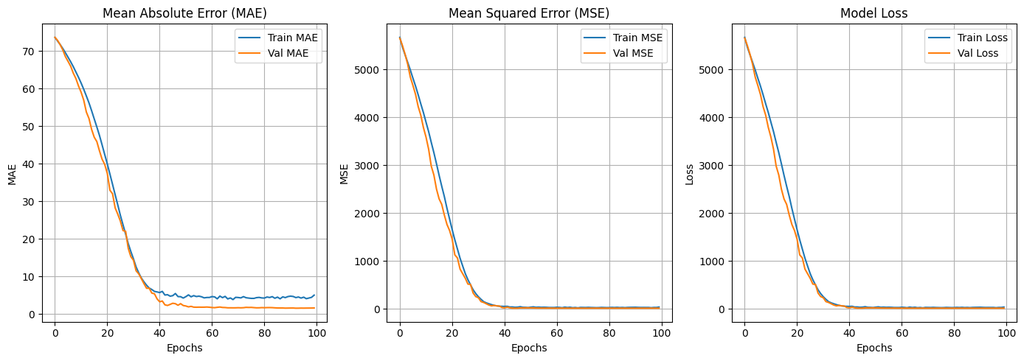

```python
import matplotlib.pyplot as plt
from sklearn.metrics import r2_score, mean_absolute_error, mean_squared_error

# Prediksi dari model
y_pred = model_2_mod.predict(X_val)

# Hitung metrik
r2 = r2_score(y_val, y_pred)
mae = mean_absolute_error(y_val, y_pred)
mse = mean_squared_error(y_val, y_pred)

# Tampilkan metrik
print(f'R² Score: {r2:.4f}')
print(f'MAE: {mae:.4f}')
print(f'MSE: {mse:.4f}')

# Plot MAE dan MSE
plt.figure(figsize=(14, 5))

# MAE
plt.subplot(1, 3, 1)
plt.plot(history_2_mod.history['mae'], label='Train MAE')
plt.plot(history_2_mod.history['val_mae'], label='Val MAE')
plt.title('Mean Absolute Error (MAE)')
plt.xlabel('Epochs')
plt.ylabel('MAE')
plt.legend()
plt.grid(True)

# MSE
plt.subplot(1, 3, 2)
plt.plot(history_2_mod.history['mse'], label='Train MSE')
plt.plot(history_2_mod.history['val_mse'], label='Val MSE')
plt.title('Mean Squared Error (MSE)')
plt.xlabel('Epochs')
plt.ylabel('MSE')
plt.legend()
plt.grid(True)

# Loss (sama dengan MSE jika loss='mse')
plt.subplot(1, 3, 3)
plt.plot(history_2_mod.history['loss'], label='Train Loss')
plt.plot(history_2_mod.history['val_loss'], label='Val Loss')
plt.title('Model Loss')
plt.xlabel('Epochs')
plt.ylabel('Loss')
plt.legend()
plt.grid(True)

plt.tight_layout()
plt.show()
```

Evaluasi

- Baseline (Sequential VS Functional)

- Modification (Sequential VS Functional)

Hasil menunjukkan bahwa Functional memiliki prediksi yang lebih baik dibandingkan dengan Sequential. Hal ini dikarenakan beberapa faktor:

1. Kapasitas Model: Model 2 punya arsitektur lebih dalam dan lebar, yang memungkinkan: • Menangkap relasi kompleks Model 1 terlalu kecil, tidak cukup sehingga hasilnya underfit total.
2. Dropout & Regularisasi Model 2 punya dropout bertingkat, artinya: • Layer awal yang besar → dropout lebih tinggi (0.4) • Layer makin kecil → dropout makin ringan (0.2) Ini mengontrol overfitting dengan cerdas, sementara Model 1 flat dropout 0.2 di semua layer mungkin kurang regularisasi untuk layer awal atau terlalu banyak untuk layer kecil.
3. Aktivasi Function Model 1 pakai ELU semua Model 2b gabung ReLU (untuk layer besar) dan ELU (di layer tengah) • ReLU cocok di layer awal yang besar: cepat, simpel • ELU bagus di layer tengah buat menangani nilai kecil dan stabilitas
4. Optimizer & Learning Rate • Model 1: learning rate terlalu kecil → lambat belajar, riskan stuck • Model 2b: 0.001 ditambah ReduceLROnPlateau → belajar cepat, lalu pelan saat mendekati minimum

```python
#@title Convert ipynb to HTML in Colab
# Upload ipynb
from google.colab import files
f = files.upload()

# Convert ipynb to html
import subprocess
file0 = list(f.keys())[0]
_ = subprocess.run(["pip", "install", "nbconvert"])
_ = subprocess.run(["jupyter", "nbconvert", file0, "--to", "html"])

# download the html
files.download(file0[:-5]+"html")
```

Upload widget is only available when the cell has been executed in the current browser session. Please rerun this cell to enable.

```
Saving 1B_bener (1).ipynb to 1B_bener (1).ipynb
```